# EconGrowthFinal slides

<br/>@Chasemoabery: Hey, does anyone know how population affects economic growth and the economy? I was doing some research the other day, and I saw something that I didn’t know if it was right or not… The bigger the populat ion in your country is, the bigger the economic growth. How do you measure economic growth? Anyway, I hope someone can answer this question!

@Davidjohnson: Hey @chasemoabery, I was just scrolling through my feed and happened to come across your comment! The best way, in my opinion, to measure economic growth is through GDP, so I would start there and see if there is any type of relationship between the economy and its population.

@Chasemoabery: That’s a good idea! I’ll start pounding away at some data and see what I can find.

@Chasemoabery: I’ve been doing some digging and preliminarily it looks to me that as a country’s population grows so does a country’s economy. Is this consistent with what you’ve found? This seems like a really important question that has plenty of real world and policy applications.

@Davidjohnson: Yeah, I completely agree. This issue is critical to more fully understand, especially in the modern day, as politicians and supranational organizations try to balance the strain a growing population can have on countries’ infrastructure needs with the assumed promise of increased productivity from more workers. I know countries like China have implemented drastic policies limiting how many children their citizens can have because of these infrastructural and overpopulation concerns. Shedding some light on the relationship between population and economic growth could help us better understand why these countries put policies like the One Child Policy into place and whether they’re effective or not, especially if we can make causal claims with the data we find.

@TheEconomistsofOZak: Hi guys @chasemoabery and @Davidjohnson! I hope you guys are doing well. I am a young, ambitious economist looking to help answer your question. David, you are right! GDP is an excellent way of measuring economic growth in a country. There is a couple of things that you need to note first!!! You might want to try using a directed acyclic graph, also known as a DAG. A DAG helps map out causal relationships between population and economic growth. I think it’ll help us to check whether these relationships are direct or if there could be other variables at play in between these changes we’re seeing.

@Chasemoabery: Woah, a DAG I have never even heard of that! @TheEconomistsofOZak How would we answer this question? Is there a best way to go about this question?

@TheEconomistsofOZak: Hi again, @chasemoabery, so the best way to answer this question is by probably creating a model. By comparing the populations of countries and the GDPs, you will be able to see that there is a type of relationship here between these two! You will also need sources, so I suggest checking out The World Bank and IPUMS (which originally stood for nothing lol). I suggest using Jupyter labs and Github to help you use the data you find from those sources and attack this question head-on! Have fun and let me know if you need any more help! You guys should get started AS SOON AS POSSIBLE! #GrindModeActivated #ECON #4362

@EconomistsofOZak: Alright gentlemen, I think enough time has elapsed. Come to me with the data you gathered and let’s see if we can’t make some causal conclusions or at least strong correlations to color in the relationship between population growth and GDP.

@ChaseMoabery: You have impeccable timing as always @EconomistsofOZak. We have in fact just finished gathering our data. We used a data aggregate source called WorldOMeter, which pulls its data from the United Nations Population Division, World Health Organization (WHO), Food and Agriculture Organization (FAO), International Monetary Fund (IMF), and World Bank.

@DavidJohnson: The data we have collected is Country name, GDP(nominal, 2017), GDP growth, Population(2017), GDP per Capita, and Share of the World GDP. In a simple web search, I found a website that compiles data from the IMF and Worldbank, so I was able to web scrape this and start on the graphs. By using Jupyter labs we will be able to use the data to produce a graphical depiction.

@EconomistsofOZak: Very interesting, gentlemen, well done. Are you sure your sources are using correct and valid data? How did they gather it? If you said you discovered this data with a simple google search, how do you know the data can be relied upon?

@ChaseMoabery: The site we used cites reputable sources that are often cited by economists and governments around the globe. But in order to do our due diligence, we even went a step further and checked where those sources got their data from and how that data was collected.

@DavidJohnson: Exactly. The primary sources used by the data aggregation site we pulled our data from collects their data in primarily two ways. The first - at the scale of these organizations (The World Bank, IMF, etc.) those can reach out to national governments directly and acquire near pinpoint accurate numbers from their country-level statistical systems that these governments use for internal purposes. The second is actually through surveying households, business establishments, NGOs, and other national or international actors within these countries themselves. There is no more reliable method of statistical data available to the general public than has been provided by these organizations.

@TheEconomistsofOZak: Alright, I’m sold. As an economist myself, I am of course aware of the validity and veracity of these sources, I would simply just have been remiss if I didn’t make sure my apprentices weren’t taking everything they saw on the first page of google at face value. Let’s get straight into it then! How will this data in particular help you answer your question - that of the relationship between population and GDP? With the data you’ve pulled from the data aggregation sites, what kinds of analyses do you intend on performing?

@ChaseMoabery: Thankfully our question is relatively straightforward and there are relatively straightforward ways to go about testing our theory - that population does have an impact on a country’s economy, measured through that country’s GDP. We predict that there is a positive correlation between population and GDP, which will show that as countries grow larger, so too do their economies. The more households they have within their borders, the bigger their industries will be, burgeoning and stretching the bounds of their economies as they climb to new steady state levels to match population.

@DavidJohnson: Additionally, we plan on running multiple analyses on the data we gather. We will use the Ordinary Least Squares method to fully visualize the correlational relationship between population and GDP. First, we will run a log log regression of population onto GDP. We chose a log log regression due to the large variance between the datapoints on both of the axes - population and GDP. The smallest country's population pitted against the largest country's population results in a difference so vast the graph would be rendered nearly useless as a visual aid from which to draw conclusions. The same goes for these countries' GDPs - there is simply too vast a difference between the minimum and maximum that anything except a log log regression would be unreadable.

@ChaseMoabery: After that regression we plan on running a second regression, this time a level log regression of GDP per capita, which is our measure of the economy mediated controlled for population, onto GDP growth per annum, our measure of the climb (or fall) of the economy. We needed to use another log for our x axis, as GDP per capita again has such high variance between the maximum and the minimum that we are left with no other choice. GDP growth, however, faces no such problem, with variance being within the realms of readability for that variable.

@DavidJohnson: That is to say - this is what we want to do. Actually doing it, writing the code ourselves seems to be giving us more difficulty than we anticipated. We were hoping that as an accomplished economist you might have already had some experiences with these programs and analyses.

@EconomistsofOZak: Nope. Sorry, can’t help you.

@ChaseMoabery: Uh, sir?

@DavidJohnson: Please tell us you’re joking. You are legitimately our only hope.

@EconomistsofOZak: Of course boys, us economists don’t really get out much so we take our laughs where we can get them. Anyways, let’s begin. First you’re going to need to launch Jupyter through Anaconda Navigator. Your professor may have had you create a special environment for your course - if so, make sure you launch Jupyter from that subspace. After that you're gonna need to download a number of different packages to augment your basic Python program so you can import your data and run your analyses. Start with importing os, requests, and io, which will allow you to access websites and files found on the internet. Then, you must import matplotlib in order to make use of its graphical functions. Import plotyly and seaborn as well while you’re at it, to offer additional plotting tools.

```python
# Download all starting packages that may be needed
# Basic Packages
from __future__ import division
import os
from datetime import datetime

# Web & file access
import requests
import io

# Import display options for showing websites
from IPython.display import IFrame, HTML

# Plotting
import matplotlib as mpl
import matplotlib.pyplot as plt
import matplotlib.ticker as mtick

import seaborn as sns

%pylab --no-import-all
%matplotlib inline

import seaborn as sns
sns.set(rc={'figure.figsize':(11.7,8.27)})
sns.set_context("talk")

import plotly.express as px
import plotly.graph_objects as go

!pip install plotnine
from plotnine import ggplot, geom_point, aes, stat_smooth, facet_wrap
# Next line can import all of plotnine, but may overwrite things? Better import each function/object you need
#from plotnine import *
```

```
Using matplotlib backend: <object object at 0x1183b56f0>
%pylab is deprecated, use %matplotlib inline and import the required libraries.
```

@ChaseMoabery: Alright sir, thank you. We’ve set up the initial code and have begun the process of preparing Python to import our data. We imported pandas and numpy, as well as pandas datareader.

@DavidJohnson: We additionally imported various geographical subprograms like geopandas and geoplot to make use of their GIS and mapping functions.

```python
# Data
import pandas as pd
import numpy as np
#!sudo python3 -m pip install pandas_datareader
from pandas_datareader import data, wb

# GIS & maps
import geopandas as gpd
gp = gpd
import georasters as gr
import geoplot as gplt
import geoplot.crs as gcrs
import mapclassify as mc
import textwrap
```

@EconomistsofOZak: Well done, gentlemen! That is exact next step I was about to recommend to you. Since you’ve already moved ahead, I would now suggest you begin data munging. Import difflib, pycountry, and geocoder. Then, begin to set up your table by creating different variables and setting them equal to the different countries you’ve just imported. Then, import norm from scipy.sats, as well as statsmodels.formula.api to set up the tools that you will use later to run your OLS regressions.

```python
# Data Munging
from itertools import product, combinations
import difflib
import pycountry
import geocoder
from geonamescache.mappers import country
mapper = country(from_key='name', to_key='iso3')
mapper2 = country(from_key='iso3', to_key='iso')
mapper3 = country(from_key='iso3', to_key='name')

# Regressions & Stats
from scipy.stats import norm
import statsmodels.formula.api as smf
#from stargazer.stargazer import Stargazer, LineLocation
```

@ChaseMoabery: Wow, that’s a lot of importing. Thank you boss, we couldn’t have gotten this far without you.

@DavidJohnson: Seriously. No idea how people do this for a living. We’ve gone ahead and done the pathing for the project, where we will create places in the devices directory to store the data and graphs we get.

```python
# Paths
pathout = './data/'

if not os.path.exists(pathout):
    os.mkdir(pathout)

pathgraphs = './graphs/'
if not os.path.exists(pathgraphs):
    os.mkdir(pathgraphs)
```

@EconomistsofOZak: Alright, great work. Now it’s time to finally pull these graphs together create a couple variables where you will store the URL of the website that has the data you want to collect, as well as a dictionary which will store your computer and operating system information. Then, pull the GDP, and call the variable.

```python
#Get Data of GDP. In this case worldmeters uses IMF and World bank so it is the easiest to use for Pandas.
url = 'https://www.worldometers.info/gdp/gdp-by-country/'

header = {
  "User-Agent": "Mozilla/5.0 (X11; Linux x86_64) AppleWebKit/537.36 (KHTML, like Gecko) Chrome/50.0.2661.75 Safari/537.36",
  "X-Requested-With": "XMLHttpRequest"
}

r = requests.get(url, headers=header)

GDP = pd.read_html(r.text)[0]

#GDP = pd.read_html(url, encoding='utf-8')[0]
GDP

GDP
```

|  | # | Country | GDP (nominal, 2017) | GDP (abbrev.) | GDP growth | Population (2017) | GDP per capita | Share of World GDP |
| --- | --- | --- | --- | --- | --- | --- | --- | --- |
| 0 | 1 | United States | $19,485,394,000,000 | $19.485 trillion | 2.27% | 325084756 | $59,939 | 24.08% |
| 1 | 2 | China | $12,237,700,479,375 | $12.238 trillion | 6.90% | 1421021791 | $8,612 | 15.12% |
| 2 | 3 | Japan | $4,872,415,104,315 | $4.872 trillion | 1.71% | 127502725 | $38,214 | 6.02% |
| 3 | 4 | Germany | $3,693,204,332,230 | $3.693 trillion | 2.22% | 82658409 | $44,680 | 4.56% |
| 4 | 5 | India | $2,650,725,335,364 | $2.651 trillion | 6.68% | 1338676785 | $1,980 | 3.28% |
| ... | ... | ... | ... | ... | ... | ... | ... | ... |
| 185 | 186 | Micronesia | $336,427,500 | $336 million | 3.20% | 532899 | $631 | 0.00% |
| 186 | 187 | Palau | $289,823,500 | $290 million | -3.57% | 17808 | $16,275 | 0.00% |
| 187 | 188 | Marshall Islands | $204,173,430 | $204 million | 3.60% | 58058 | $3,517 | 0.00% |
| 188 | 189 | Kiribati | $185,572,502 | $186 million | 0.33% | 114158 | $1,626 | 0.00% |
| 189 | 190 | Tuvalu | $39,731,317 | $40 million | 3.24% | 11370 | $3,494 | 0.00% |

190 rows × 8 columns

@ChaseMoabery: Wow, honestly, I was not expecting that to work so smoothly. It’s remarkable how powerful these tools are. Next, we’re going to import IFrame so we have options to display data from websites.

@DavidJohnson: Right. We need this so we can easily pull the country codes from Wikipedia. We’re planning on merging these country codes with our original GDP dataset from WorldoMeters to increase the readability of our chart.

```python
# Import display options for showing websites
from IPython.display import IFrame
url = 'https://en.wikipedia.org/wiki/List_of_ISO_3166_country_codes'

isocodes = pd.read_html(url, encoding='utf-8')[0]
isocodes

isocodes = isocodes.droplevel(0, axis=1)
isocodes.head()

mycols = isocodes.columns
mycols = [c[:c.find('[')] for c in mycols]
mycols

isocodes.columns = mycols
isocodes.head()

isocodes['Alpha-2 code original'] = isocodes['Alpha-2 code']
isocodes['Alpha-2 code'] = isocodes['Subdivision code links'].apply(lambda x: x[x.find(':')+1:])
isocodes.head()

isocodes = isocodes.drop(columns = (["Official state name", "Sovereignty", "Alpha-2 code", "Numeric code", "Subdivision code links", "Internet ccTLD", "Alpha-2 code original"]))

isocodes
```

|  | Country name | Alpha-3 code |
| --- | --- | --- |
| 0 | Afghanistan | AFG |
| 1 | Åland Islands | ALA |
| 2 | Albania | ALB |
| 3 | Algeria | DZA |
| 4 | American Samoa | ASM |
| ... | ... | ... |
| 266 | Wallis and Futuna | WLF |
| 267 | Western Sahara [ai] | ESH |
| 268 | Yemen | YEM |
| 269 | Zambia | ZMB |
| 270 | Zimbabwe | ZWE |

271 rows × 2 columns

@EconomistsofOZak: Great work. Now clean all this up - use Python’s basic merge function to add this new data into your existing charts. Drop the columns you don’t need to make sure everything stays tight.

```python
# After importing ISO codes we can add them to the overall data table by merging them with the existing table we have.
merged = isocodes.merge(GDP, left_on='Country name', right_on='Country')
merged
```

|  | Country name | Alpha-3 code | # | Country | GDP (nominal, 2017) | GDP (abbrev.) | GDP growth | Population (2017) | GDP per capita | Share of World GDP |
| --- | --- | --- | --- | --- | --- | --- | --- | --- | --- | --- |
| 0 | Afghanistan | AFG | 113 | Afghanistan | $19,543,976,895 | $19.54 billion | 2.67% | 36296113 | $538 | 0.02% |
| 1 | Albania | ALB | 125 | Albania | $13,038,538,300 | $13.04 billion | 3.84% | 2884169 | $4,521 | 0.02% |
| 2 | Algeria | DZA | 53 | Algeria | $167,555,280,113 | $168 billion | 1.60% | 41389189 | $4,048 | 0.21% |
| 3 | American Samoa | ASM | 182 | American Samoa | $634,000,000 | $634 million | -5.38% | 55620 | $11,399 | 0.00% |
| 4 | Andorra | AND | 159 | Andorra | $3,012,914,131 | $3.01 billion | 1.87% | 77001 | $39,128 | 0.00% |
| ... | ... | ... | ... | ... | ... | ... | ... | ... | ... | ... |
| 144 | Uzbekistan | UZB | 83 | Uzbekistan | $49,677,172,714 | $49.68 billion | 5.30% | 31959785 | $1,554 | 0.06% |
| 145 | Vanuatu | VUT | 179 | Vanuatu | $862,879,789 | $863 million | 4.50% | 285510 | $3,022 | 0.00% |
| 146 | Yemen | YEM | 98 | Yemen | $31,267,675,216 | $31.27 billion | -5.94% | 27834819 | $1,123 | 0.04% |
| 147 | Zambia | ZMB | 102 | Zambia | $25,868,142,073 | $25.87 billion | 3.40% | 16853599 | $1,535 | 0.03% |
| 148 | Zimbabwe | ZWE | 110 | Zimbabwe | $22,040,902,300 | $22.04 billion | 4.70% | 14236595 | $1,548 | 0.03% |

149 rows × 10 columns

```python
# We drop columns that we do not need
merged = merged.drop(columns = ['#', 'Country'])
```

```python
merged
```

|  | Country name | Alpha-3 code | GDP (nominal, 2017) | GDP (abbrev.) | GDP growth | Population (2017) | GDP per capita | Share of World GDP |
| --- | --- | --- | --- | --- | --- | --- | --- | --- |
| 0 | Afghanistan | AFG | $19,543,976,895 | $19.54 billion | 2.67% | 36296113 | $538 | 0.02% |
| 1 | Albania | ALB | $13,038,538,300 | $13.04 billion | 3.84% | 2884169 | $4,521 | 0.02% |
| 2 | Algeria | DZA | $167,555,280,113 | $168 billion | 1.60% | 41389189 | $4,048 | 0.21% |
| 3 | American Samoa | ASM | $634,000,000 | $634 million | -5.38% | 55620 | $11,399 | 0.00% |
| 4 | Andorra | AND | $3,012,914,131 | $3.01 billion | 1.87% | 77001 | $39,128 | 0.00% |
| ... | ... | ... | ... | ... | ... | ... | ... | ... |
| 144 | Uzbekistan | UZB | $49,677,172,714 | $49.68 billion | 5.30% | 31959785 | $1,554 | 0.06% |
| 145 | Vanuatu | VUT | $862,879,789 | $863 million | 4.50% | 285510 | $3,022 | 0.00% |
| 146 | Yemen | YEM | $31,267,675,216 | $31.27 billion | -5.94% | 27834819 | $1,123 | 0.04% |
| 147 | Zambia | ZMB | $25,868,142,073 | $25.87 billion | 3.40% | 16853599 | $1,535 | 0.03% |
| 148 | Zimbabwe | ZWE | $22,040,902,300 | $22.04 billion | 4.70% | 14236595 | $1,548 | 0.03% |

149 rows × 8 columns

@ChaseMoabery: Alright, we’ve done all the setup we can I believe. Now it’s time to actually run the ordinary least squares analyses.

@DavidJohnson: Not going to lie Mr. Economists, we’re kind of at a loss here. We don’t even know where to begin with these regressions.

@EconomistsofOZak: Tough luck.

@ChaseMoabery: …

@DavidJohnson: …

@EconomistsofOZak: Kidding, of course. Just wanted to watch you all sweat a little. The code required is very far beyond anything entry level coders like yourselves could be expected to accomplish. Luckily, I’ve run many similar regressions in my days as an economist. Try adapting this code for your purposes.

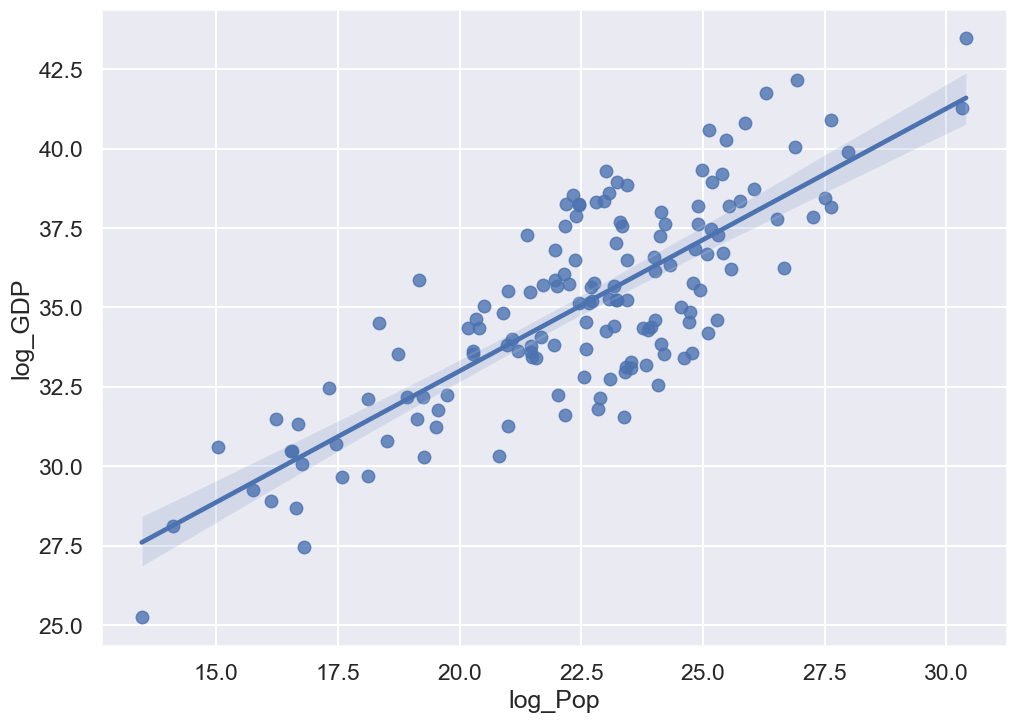

```python
#Confugring sns based on example
sns.set(rc={'figure.figsize':(11.7,8.27)})
sns.set_context("talk")

#Creates deep copy of merged df
new_df = merged

#Sorts the entries of DF by population
new_df.sort_values(by='Population (2017)', inplace=True)

#Creates new column log_pop which is the log of Population.
new_df['log_Pop'] = np.log2(new_df['Population (2017)'])

#Changing the Obj (ie String) datatype of nominal GDP into int so that we can do log operation on it
GDP = []
for val in new_df['GDP (nominal, 2017)']: #Iterates through nominal GDP column
    GDP.append(val.replace("$","").replace(",","")) #Removes $ and ,'s from data allowing for conversion to floats
new_df['GDP'] = GDP #inserts new values into dataframe
new_df['GDP'] = new_df['GDP'].astype(int) #Casts data type from Obj to into
new_df['log_GDP'] = np.log2(new_df['GDP'])
sns.regplot(data=new_df, x='log_Pop', y='log_GDP') #Generates plot using seaborn
```

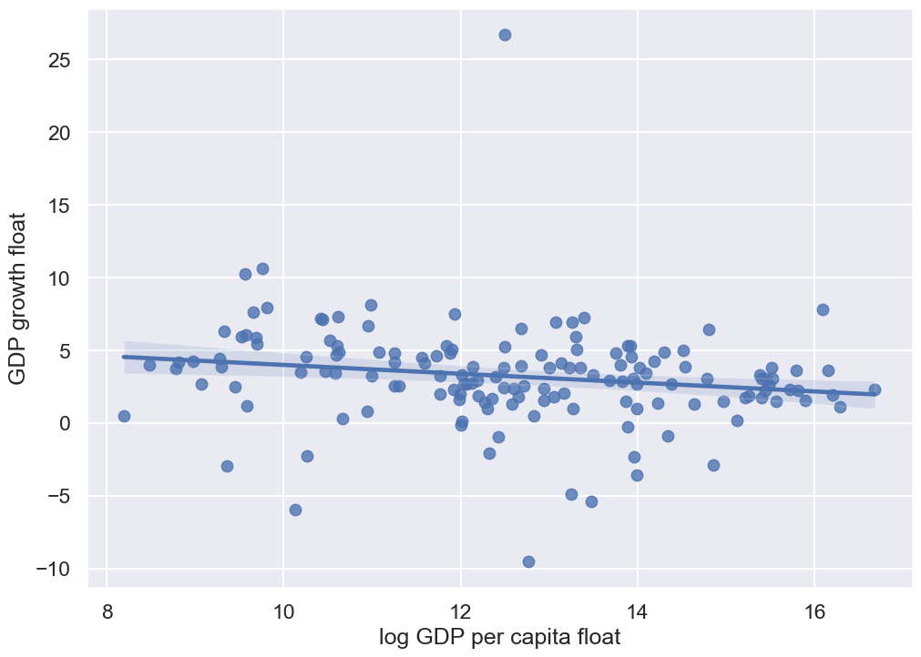

```python
sns.set(rc={'figure.figsize':(11.7,8.27)})
sns.set_context("talk")

#Change GDP growth into float64
GDP_growth = []
for val in new_df['GDP growth']:
    val = val[:-1] #Removes the '%' from the end of GDP growth values
    GDP_growth.append(float(val)) #Converts vals to floats and appends them to the array GDP_growth
new_df['GDP growth float'] = GDP_growth

#Chnage GDP per capita into float64
GDP_per_capita = []
for val in new_df['GDP per capita']:
    GDP_per_capita.append(float(val.replace("$","").replace(",",""))) #Removes $ and ,'s from values
new_df['GDP per capita float'] = GDP_per_capita

new_df['log GDP per capita float'] = np.log2(new_df['GDP per capita float']) #Puts on log scale

new_df.sort_values(by='log GDP per capita float', inplace=True) #Sorts data frame by log GDP per capita

sns.regplot(data=new_df, x='log GDP per capita float', y='GDP growth float') #Seaborn plot
```

@EconomistsofOZak: Fascinating stuff, gentlemen. These ordinary least square regressions absolutely give strong evidence to the claims you’ve been making about population and GDP. I’m seeing that as population increases, so too does GDP. However, I am also seeing that as GDP per capita increases, GDP growth decreases. Is that accurate? What are your all’s thoughts on this phenomenon?

@TheEconomistsofOZak: Well done gentlemen. A great analysis with great graphs and a great attitude. Overall what did we learn?

@ChaseMoabery: We learned that as predicted, larger countries tend to have larger GDPs. These countries have more workers and more households, so their GDPs tend to be larger than smaller countries, even if per capita productivity is less. GDP and total population are therefore positively correlated. This positive correlation however does not extend to the growth rate of the economy.

@EconomistsofOZak: Well done gentlemen. It looks and sounds like we’ve reached the end of a fruitful search for an answer to a seemingly obvious question: how does population affect an economy. It was a joy working with you both.

[figure not shown]